# IDE-introduce-ipython

## IPython 工具使用

- 命令行中输入ipython

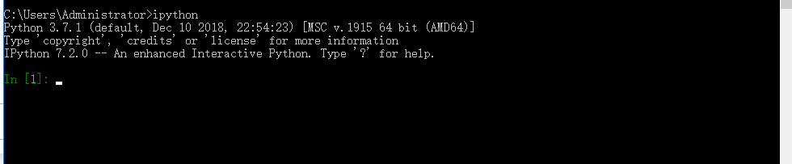

```python
from IPython.display import Image
Image("./imgs/ipython1.png")
```

- 测试pytorch

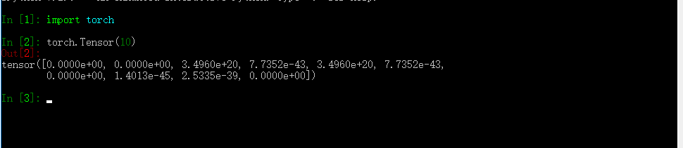

```python
from IPython.display import Image
Image("./imgs/ipython2.png")
```

## IPthon magic命令

- %作用于一行代码，%%作用于cell
- %%capture 屏蔽当前cell打印
- 与系统命令交互，前面加!：! ping www.baidu.com
- tab 自动补全
- shift + tab 查看文档，多按几次效果不同
- _表示使用上一个cell的结果
- sum? sum?? 查看文档
- %pdoc objctname 查看对象的文档
- %psource objctname 查看源码
- %pdef funcname 查看函数定义
- %pfile objctname 查看所有源码文件
- %quickref 显示IPython的快速参考
- %magic 显示所有魔术命令的详细文档
- %lsmagic 显示所有魔术命令
- %debug 从最新的异常跟踪的底部进入交互式调试器
- %hist 打印命令的输入（可选输出）历史
- %pdb 在异常发生后自动进入调试器
- %paste 执行剪贴板中的Python代码
- %cpaste 打开一个特殊提示符以便手工粘贴待执行的Python代码
- %reset 删除interactive命名空间中的全部变量/名称
- %page OBJECT 通过分页器打印输出OBJECT
- %run script.py 在IPython中执行一个Python脚本文件
- %prun statement 通过cProfile执行statement，并打印分析器的输出结果。
- %prun 可显示运行时间
- %time statement 报告statement的执行时间
- %timeit statement 多次执行statement以计算系综平均执行时间。
- %who、%who_ls、%whos 显示interactive命名空间中定义的变量，信息级别/冗余度可变
- %xdel variable 删除variable，并尝试清除其在IPython中的对象上的一切引用
- %pwd 目前工作文件夹
- %reset_f 重置变量空间
- %mkdir %cd %ls %rmdir 类似于dos的文件夹相关命令**

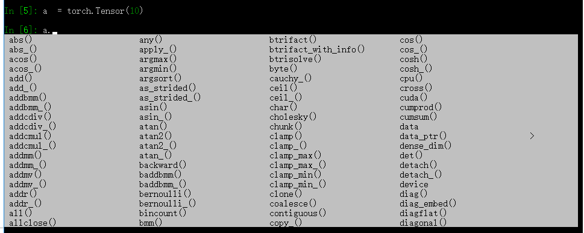

```python
from IPython.display import Image
Image("./imgs/ipython3.png")
```